# Merging mixture components

Marc Comas-Cufí

2017-01-26

The most standard parametric approach in cluster analysis assumes data can be modelled by a finite mixture distribution. The approach has two steps; first, a finite mixture distribution with probability density function
$$f(\;\cdot\; ; \pi_1, \dots, \pi_k, \theta_1, \dots, \theta_k) = \pi_1 (\;\cdot\; ; \theta_1) + \dots + \pi_k f(\;\cdot\; ; \theta_k),$$
with $\sum_{j=1}^k = \pi_j =1$ is fitted to a sample $ X$, obtaining estimates $\hat{\pi}_1, \dots, \hat{\pi}_k$ and $\hat{\theta}_1 \dots \hat{\theta}_k$. After the fitting process, each observation $ x$ is assigned to the finite mixture component $j$, $1\leq j \leq k$, with $\hat{\pi}_j f( x ; \hat{\theta}_j)$ maximum.

We are going to work with the dataset ex4.1 used in Baudry et el. (2010) and available in package `mclust`. To fit a finite mixture of gaussian distributions we are going to use the same package.

```r
library(mclust)
library(mixpack)
library(ggplot2)
library(dplyr)
```

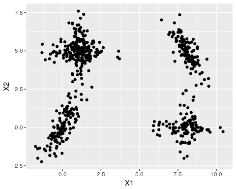

```r
data(Baudry_etal_2010_JCGS_examples)
qplot(data=ex4.1, X1, X2)
```

# Finite mixture fitting

Function `Mclust` allows us to fit a mixture function to a dataset.

```r
m <- Mclust(ex4.1)
summary(m)
```

```
## ----------------------------------------------------
## Gaussian finite mixture model fitted by EM algorithm
## ----------------------------------------------------
##
## Mclust EEV (ellipsoidal, equal volume and shape) model with 6 components:
##
##  log.likelihood   n df       BIC       ICL
##       -1957.786 600 25 -4075.494 -4248.158
##
## Clustering table:
##   1   2   3   4   5   6
##  79 122 121 107 132  39
```

Using the function `dmixnorm_solution` we can evaluate the probability density function and calculate the posterior probabilities

```r
dens.mixt = dmixnorm_solution(ex4.1, solution = m)
(df <- lapply(1:6, function(i)
  (m$parameters$pro[i] * dmixnorm_solution(ex4.1, solution = m, part=i)) %>%
    data.frame %>% {./dens.mixt} %>%
    setNames(sprintf('p%02d', i)) ) %>% bind_cols) %>% tbl_df
```

```
## # A tibble: 600 × 6
##             p01           p02          p03           p04           p05
##           <dbl>         <dbl>        <dbl>         <dbl>         <dbl>
## 1  2.822820e-02  2.243024e-24 8.770852e-86 7.056364e-102 8.334248e-122
## 2  9.727873e-01  1.736318e-24 3.126308e-61  2.072396e-81  3.027038e-90
## 3  3.714200e-35  9.994207e-01 3.467474e-14 8.608995e-117  1.435930e-80
## 4  1.863401e-42  1.061134e-81 1.111488e-01  8.887923e-01  5.891570e-05
## 5  3.867843e-35  4.611201e-94 1.033876e-03  9.983918e-01  5.742791e-04
## 6  1.034939e-17 8.673403e-226 4.242040e-72  1.854718e-14  1.000000e+00
## 7  1.537934e-14 2.954088e-163 3.138887e-30  7.025241e-06  9.999930e-01
## 8  6.262560e-51  1.300271e-87 3.816734e-01  6.183265e-01  6.164994e-08
## 9  2.142260e-50  4.820499e-76 5.404207e-01  4.595778e-01  1.582597e-06
## 10 5.674921e-61  9.999993e-01 1.246030e-10  2.430742e-99  2.604146e-58
## # ... with 590 more rows, and 1 more variables: p06 <dbl>
```

The posterior probabilities are also available in the object returned by function `Mclust`.

```r
m$z %>% tbl_df
```

```
## # A tibble: 600 × 6
##              V1            V2           V3            V4            V5
##           <dbl>         <dbl>        <dbl>         <dbl>         <dbl>
## 1  2.850411e-02  2.310219e-24 9.282937e-86 7.504895e-102 9.048667e-122
## 2  9.727797e-01  1.765001e-24 3.220138e-61  2.153801e-81  3.181109e-90
## 3  3.921316e-35  9.994268e-01 3.474206e-14 9.224481e-117  1.498631e-80
## 4  1.822696e-42  1.106672e-81 1.112261e-01  8.887149e-01  5.894606e-05
## 5  3.774169e-35  4.850409e-94 1.036081e-03  9.983893e-01  5.746424e-04
## 6  1.042332e-17 1.003888e-225 4.429355e-72  1.864876e-14  1.000000e+00
## 7  1.509739e-14 3.263020e-163 3.195662e-30  7.038944e-06  9.999930e-01
## 8  6.098899e-51  1.357183e-87 3.817205e-01  6.182795e-01  6.176813e-08
## 9  2.097704e-50  5.003153e-76 5.404484e-01  4.595500e-01  1.583895e-06
## 10 6.084225e-61  9.999993e-01 1.246642e-10  2.579598e-99  2.676552e-58
## # ... with 590 more rows, and 1 more variables: V6 <dbl>
```

```r
xlimits = seq(-3, 11, 0.05)
ylimits = seq(-3, 8, 0.05)
cm0 = expand.grid(X1 = xlimits, X2 = ylimits) %>% tbl_df %>%
  mutate(z = dmixnorm_solution(., solution=m))
```

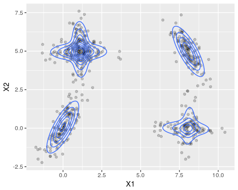

```r
ggplot() +
  geom_point(data=ex4.1, aes(x=X1, y=X2),alpha=0.2) +
  stat_contour(data = cm0, aes(x=X1, y=X2, z=z))
```

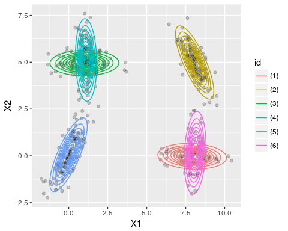

```r
partition = list(1,2,3,4,5,6)
CN6 = lapply(partition, function(part){
  expand.grid(X1 = xlimits, X2 = ylimits) %>%
    tbl_df %>%
    mutate(z = dmixnorm_solution(., m, part = part),
           id = sprintf('{%s}',paste(part, collapse=',')))
}) %>% bind_rows

ggplot() +
  geom_point(data=ex4.1, aes(x=X1, y=X2),alpha=0.2) +
  stat_contour(data = CN6, aes(x=X1, y=X2, z=z, col=id))
```

## Using a specific partition

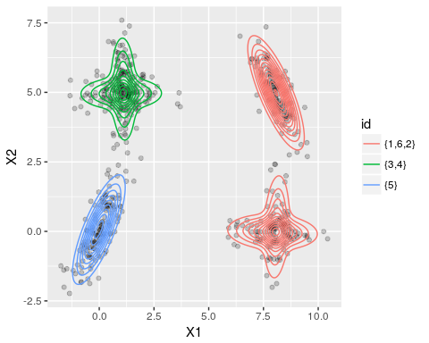

```r
partition = list(c(1,6,2),c(3,4),5)
CN6 = lapply(partition, function(part){
  expand.grid(X1 = xlimits, X2 = ylimits) %>%
    mutate(z = dmixnorm_solution(., m, part = part),
           id = sprintf('{%s}',paste(part, collapse=',')))
}) %>% bind_rows

ggplot() +
  geom_point(data=ex4.1, aes(x=X1, y=X2),alpha=0.2) +
  stat_contour(data = CN6, aes(x=X1, y=X2, z=z, col=id))
```